# Επιχειρηματική Αναλυτική

Euroleague 2023-24: Statistical Excellence Report

Μαρία Μπαλαφούτη

2026-03-23

# Περιγραφή του Dataset

Το dataset περιλαμβάνει **στατιστικά στοιχεία ομάδων της EuroLeague για την αγωνιστική περίοδο 2023-2024**. Κάθε γραμμή αντιστοιχεί σε μία ομάδα, ενώ κάθε στήλη περιέχει έναν συγκεκριμένο δείκτη απόδοσης που σχετίζεται με την επίθεση, την άμυνα ή τη συνολική απόδοση της ομάδας.

- **Πηγή:** Τα δεδομένα αντλήθηκαν από την πλατφόρμα [3stepsbasket.com](https://3stepsbasket.com/euroleague/charts?season=euroleague-2024).
- **Πληθυσμός:** Οι 18 ομάδες που αγωνίστηκαν στην κανονική διάρκεια και τα playoffs της διοργάνωσης.

# Αναλυτική Επεξήγηση Μεταβλητών

**Γενικά Δεδομένα**

- **Club:** Το όνομα της ομάδας της EuroLeague.
- **GMS (Games):** Ο συνολικός αριθμός αγώνων που έπαιξε η ομάδα στη σεζόν.
- **MIN (Minutes):** Ο μέσος χρόνος αγώνα σε λεπτά (περίπου 40 λεπτά).
- **PTS+ (Points Scored):** Ο μέσος αριθμός πόντων που σκοράρει η ομάδα ανά αγώνα.
- **PTS- (Points Allowed):** Ο μέσος αριθμός πόντων που δέχεται η ομάδα ανά αγώνα.

**Στατιστικά Σουτ**

- **2PM / 2PA:** Εύστοχα δίποντα και προσπάθειες για δίποντο ανά αγώνα.
- **2FG%:** Το ποσοστό ευστοχίας στα δίποντα.
- **3PM / 3PA:** Εύστοχα τρίποντα και προσπάθειες για τρίποντο ανά αγώνα.
- **3FG%:** Το ποσοστό ευστοχίας στα τρίποντα.

**Φάουλ & Βολές**

- **PF Committed:** Ο μέσος αριθμός φάουλ που κάνει η ομάδα.
- **PF Drawn:** Ο μέσος αριθμός φάουλ που κερδίζει η ομάδα.
- **FTM / FTA:** Εύστοχες ελεύθερες βολές και προσπάθειες ανά αγώνα.
- **FT%:** Το ποσοστό ευστοχίας στις ελεύθερες βολές.

**️ Ριμπάουντ & Άμυνα**

- **OR / DR:** Επιθετικά και αμυντικά ριμπάουντ ανά αγώνα.
- **REB:** Ο συνολικός αριθμός ριμπάουντ (OR + DR).
- **BLK (Blocks):** Ο μέσος αριθμός κοψιμάτων (μπλοκ) ανά αγώνα.

**Δημιουργία Παιχνιδιού**

- **AST (Assists):** Ο μέσος αριθμός ασίστ ανά αγώνα.
- **TOV (Turnovers):** Ο μέσος αριθμός λαθών ανά αγώνα (χαμένες κατοχές).

# Επιχειρηματική Αξία

- **Βελτιστοποίηση Απόδοσης:** Οι ομάδες λειτουργούν ως οργανισμοί που πρέπει να κατανείμουν τους πόρους τους (παίκτες, budget) με τον πιο αποδοτικό τρόπο.
- **Λήψη Αποφάσεων:** Η αναλυτική βοηθά τους προπονητές και τους managers να εντοπίζουν στρατηγικά πλεονεκτήματα, όπως η σχέση μεταξύ της ομαδικής συνεργασίας (assists) και της τελικής αποτελεσματικότητας.
- **Ανταγωνιστικό Πλεονέκτημα:** Μέσω των δεδομένων, μια ομάδα μπορεί να αναγνωρίσει τις αδυναμίες των αντιπάλων της και να προσαρμόσει την τακτική της.

## Φόρτωση Βιβλιοθηκών

```r
library(ggplot2)
library(dplyr)
library(tidyr)
library(DT)
```

## Φόρτωση Dataset

```r
euro_data <- read.csv("euro_data.csv", check.names = TRUE)
```

## Προβολή Dataset

```r
datatable(euro_data,
          options = list(pageLength = 10, scrollX = TRUE),
          caption = 'Ολόκληρο το Dataset της Euroleague 2023-24')
```

|  | Club | GMS | MIN | PTS. | PTS..1 | X2PM | X2PA | X2FG. | X3PM | X3PA | X3FG. | FTM | FTA | FT. | OR | DR | REB | AST | TOV | BLK | PF | PF.1 |
| --- | --- | --- | --- | --- | --- | --- | --- | --- | --- | --- | --- | --- | --- | --- | --- | --- | --- | --- | --- | --- | --- | --- |
| 1 | LDLC ASVEL Villeurbanne | 34 | 40:17:00 | 78.6 | 84.9 | 21.9 | 40.8 | 53.6 | 7.2 | 21.3 | 33.7 | 13.4 | 17.3 | 77.3 | 10.2 | 23.7 | 371.7 | 17.8 | 13 | 1.6 | 18.7 | 19.6 |
| 2 | EA7 Emporio Armani Milan | 34 | 40:17:00 | 78.2 | 78.1 | 18.1 | 32.8 | 55.1 | 10 | 27.4 | 36.7 | 11.9 | 15.4 | 77.6 | 8.8 | 23.3 | 323.3 | 16.3 | 12.4 | 2.1 | 19.7 | 19.6 |
| 3 | FC Barcelona | 39 | 40:07:00 | 81.1 | 78.8 | 21.9 | 40.2 | 54.6 | 8.4 | 23.4 | 36 | 12 | 16.5 | 72.6 | 11.5 | 24.3 | 474.3 | 19.3 | 12.8 | 2.3 | 20.2 | 19.4 |
| 4 | Baskonia | 39 | 40:07:00 | 84.6 | 86.4 | 19.3 | 34.6 | 55.7 | 10.9 | 29.3 | 37.1 | 13.4 | 17.6 | 76.2 | 10.5 | 24.5 | 432.5 | 18.9 | 12.5 | 2.2 | 18.2 | 19.3 |
| 5 | Alba Berlin | 34 | 40:00:00 | 76.2 | 86.6 | 18.9 | 37.1 | 50.9 | 8.9 | 25.3 | 35.1 | 11.9 | 15 | 79.2 | 10.8 | 21.6 | 389.6 | 16.4 | 15.1 | 2.1 | 18.4 | 18.5 |
| 6 | Fenerbahce Beko Istanbul | 41 | 40:43:00 | 84.1 | 80.9 | 18.5 | 33.3 | 55.6 | 11.5 | 29.2 | 39.2 | 12.7 | 16 | 79.3 | 10.2 | 23 | 443 | 18 | 12.1 | 2.2 | 21.7 | 20.1 |
| 7 | Anadolu Efes Istanbul | 35 | 40:42:00 | 85.5 | 85.1 | 21.3 | 38.5 | 55.5 | 9.9 | 26.9 | 37 | 13 | 16 | 81.2 | 10.3 | 22.2 | 383.2 | 17.6 | 10.3 | 3.1 | 18.5 | 19.1 |
| 8 | Real Madrid | 39 | 40:46:00 | 88.7 | 81.4 | 21 | 36.3 | 58 | 10.4 | 27.6 | 37.8 | 15.3 | 18.8 | 81.5 | 9.8 | 26.6 | 408.6 | 20.6 | 12 | 3.6 | 19.1 | 20.7 |
| 9 | AS Monaco | 39 | 40:23:00 | 81.8 | 79.5 | 21.8 | 41.1 | 53 | 7.8 | 22.4 | 35 | 14.8 | 19.7 | 74.8 | 11 | 22.8 | 452.8 | 16.1 | 10 | 1.8 | 19.7 | 22 |
| 10 | FC Bayern Munich | 34 | 40:44:00 | 78.6 | 82.1 | 19.1 | 35.7 | 53.4 | 9.9 | 27.6 | 35.8 | 10.8 | 13.6 | 79.8 | 10.7 | 24.7 | 388.7 | 16 | 13 | 2.6 | 20.8 | 18.9 |

[output cut: 8 more lines]

# Επιχειρηματικά ερωτήματα

Μέσω της στατιστικής επεξεργασίας, επιδιώκουμε να απαντήσουμε στα εξής:

## 1. Η Επίδραση της Δημιουργικότητας στο Σκοράρισμα

**Σκοπός:** Η εξέταση της σχέσης μεταξύ των **Ασίστ (Assists)** και των **Συνολικών Πόντων (PTS)**. Στόχος είναι να διαπιστωθεί αν η ομαδική συνεργασία και η καλή κυκλοφορία της μπάλας μεταφράζονται άμεσα σε μεγαλύτερη επιθετική παραγωγικότητα.

**Ερώτημα**: Υπάρχει θετική συσχέτιση μεταξύ των Assists και των πόντων που σημειώνει μια ομάδα στη Euroleague;

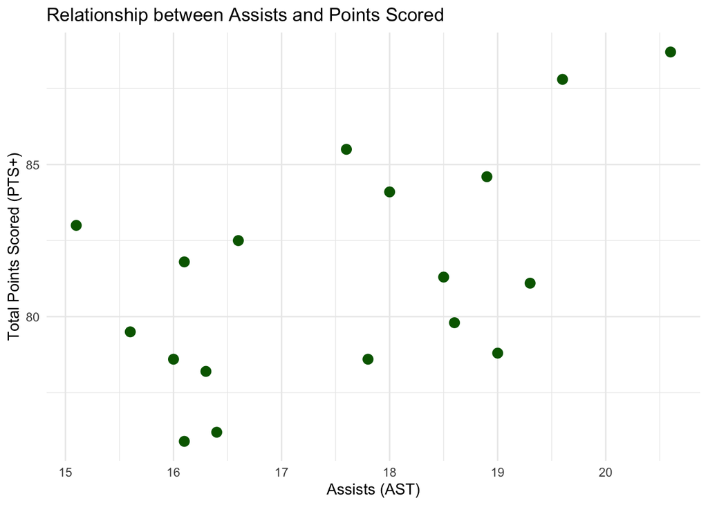

```r
# ScatterPlot
ggplot(euro_data, aes(x = AST, y = PTS.)) +
  geom_point(color = "darkgreen", size = 3) +
  labs(
    title = "Relationship between Assists and Points Scored",
    x = "Assists (AST)",
    y = "Total Points Scored (PTS+)"
  ) +
  theme_minimal()
```

### Ερμηνεία Διαγράμματος & Στρατηγική Ανάλυση

Αν εξετάσουμε τη διασπορά των σημείων στο παραπάνω γράφημα, παρατηρούμε τα εξής:

### Η σχέση δεν είναι “τέλεια”

Είναι σημαντικό να σημειωθεί ότι η συσχέτιση δεν είναι απόλυτη. Υπάρχουν αποκλίσεις όπου:

- Ορισμένες ομάδες έχουν υψηλό αριθμό ασίστ αλλά σχετικά χαμηλό σκορ.
- Άλλες ομάδες σκοράρουν αρκετά παρά τον χαμηλό αριθμό ασίστ.

Αυτό υποδηλώνει ότι το σκοράρισμα επηρεάζεται και από άλλους κρίσιμους παράγοντες, όπως:

1. **Ποσοστό ευστοχίας** (Field Goal Percentage)
2. **Ευστοχία στα τρίποντα** (3FG%)
3. **Επιθετικά ριμπάουντ** (OR) που προσφέρουν δεύτερες ευκαιρίες
4. **Ρυθμός παιχνιδιού** (Pace)

### Γιατί συμβαίνει αυτό στο μπάσκετ;

Οι ασίστ στην πράξη μεταφράζονται σε:

- **Καλύτερη κυκλοφορία** της μπάλας
- **Αποτελεσματική συνεργασία** των παικτών
- **Δημιουργία ελεύθερων σουτ** (open shots)

Συνεπώς, αυξάνονται οι πιθανότητες για ποιοτικές εκτελέσεις, οι οποίες οδηγούν σε περισσότερους πόντους και υψηλότερη επιθετική αποτελεσματικότητα.

## 2. Διαχείριση Λαθών & Αμυντική Συμπεριφορά

**Σκοπός:** Η εξέταση της σχέσης μεταξύ των **Λαθών (Turnovers)** και των **Πόντων που δέχεται μια ομάδα (Points Allowed)**. Στόχος είναι να διαπιστωθεί αν τα αυξημένα λάθη οδηγούν σε εύκολες κατοχές για τον αντίπαλο, αυξάνοντας το παθητικό της ομάδας.

**Ερώτημα:** Οι ομάδες που υποπίπτουν σε περισσότερα λάθη, δέχονται τελικά και περισσότερους πόντους;

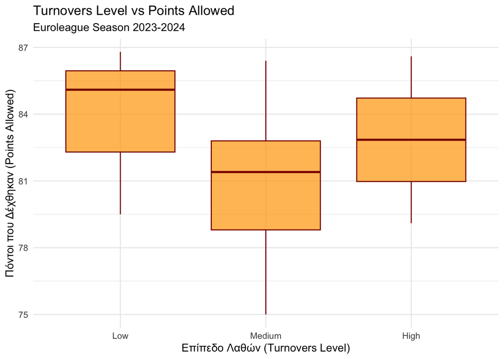

```r
# Δημιουργία νέας κατηγορικής μεταβλητής για τα Turnovers (Χώρισμα σε 3 επίπεδα)
euro_data$TOV_group <- cut(euro_data$TOV,
                           breaks = 3,
                           labels = c("Low", "Medium", "High"))

# Δημιουργία BoxPlot
# Σημείωση: Χρησιμοποιούμε το PTS..1 που αντιστοιχεί στη στήλη PTS-
ggplot(euro_data, aes(x = TOV_group, y = PTS..1)) +
  geom_boxplot(fill = "orange", color = "darkred", alpha = 0.7) +
  labs(
    title = "Turnovers Level vs Points Allowed",
    subtitle = "Euroleague Season 2023-2024",
    x = "Επίπεδο Λαθών (Turnovers Level)",
    y = "Πόντοι που Δέχθηκαν (Points Allowed)"
  ) +
  theme_minimal()
```

### Ερμηνεία Διαγράμματος & Στρατηγική Ανάλυση

Αν εξετάσουμε τα επίπεδα των λαθών στο παραπάνω γράφημα, παρατηρούμε τα εξής:

**Συσχέτιση Δεδομένων:**

- Οι ομάδες με λίγα λάθη (Low) δέχονται κατά μέσο όρο περίπου 85 πόντους.
- Οι ομάδες με μεσαία λάθη (Medium) δέχονται κατά μέσο όρο περίπου 81 πόντους.
- Οι ομάδες με πολλά λάθη (High) δέχονται κατά μέσο όρο περίπου 83 πόντους.

**Γενική Τάση:** Παραδόξως, οι ομάδες με τα λιγότερα λάθη τείνουν να δέχονται ελαφρώς περισσότερους πόντους σε σχέση με τις ομάδες της μεσαίας κατηγορίας. Αυτό δείχνει ότι δεν υπάρχει μια απλή, ευθεία σχέση μεταξύ λαθών και παθητικού.

### Η σχέση δεν είναι “τέλεια”

Είναι σημαντικό να σημειωθεί ότι η συσχέτιση δεν είναι απόλυτη. Υπάρχουν αποκλίσεις όπου:

- Ορισμένες ομάδες κάνουν αρκετά λάθη αλλά διατηρούν την άμυνά τους σε πολύ χαμηλά επίπεδα.
- Άλλες ομάδες προστατεύουν τη μπάλα (λίγα λάθη) αλλά δέχονται πολλούς πόντους.

Αυτό υποδηλώνει ότι η αμυντική απόδοση επηρεάζεται και από άλλους κρίσιμους παράγοντες, όπως:

1. **Ομαδική άμυνα** (Defensive Cohesion)
2. **Έλεγχος των ριμπάουντ** (Rebounds)
3. **Πίεση στην μπάλα** (Ball Pressure)
4. **Συνολική αμυντική τακτική** (Defensive Strategy)

### Συμπέρασμα 2ου Ερωτήματος

Συνολικά, η ανάλυση δείχνει ότι τα λάθη (turnovers) επηρεάζουν σε κάποιο βαθμό την αμυντική επίδοση, αλλά δεν αποτελούν τον μοναδικό ή τον καθοριστικό παράγοντα για τους πόντους που δέχεται μια ομάδα.

### Γιατί συμβαίνει αυτό στο μπάσκετ;

Η αμυντική απόδοση μιας ομάδας εξαρτάται από μια σειρά ενεργειών που μπορούν να “καλύψουν” τα λάθη:

- **Γρήγορες επιστροφές** (Transition Defense)
- **Κλεψίματα και τάπες** που σταματούν τον ρυθμό του αντιπάλου
- **Προστασία του καλαθιού** (Rim Protection)

Συνεπώς, αν και τα λάθη στερούν επιθέσεις, μια καλά οργανωμένη άμυνα μπορεί να αποτρέψει τη μετατροπή τους σε πόντους για τον αντίπαλο.

## 3. Σύγκριση Επιθετικής και Αμυντικής Απόδοσης

**Σκοπός:** Η σύγκριση των πόντων που σκοράρει κάθε ομάδα (Επίθεση) με τους πόντους που δέχεται (Άμυνα). Με αυτόν τον τρόπο μπορούμε να εντοπίσουμε ποιες ομάδες είναι ισορροπημένες και ποιες βασίζονται αποκλειστικά σε μία από τις δύο πλευρές του παιχνιδιού.

**Ερώτημα:** Ποιες ομάδες έχουν την καλύτερη και ποιες τη χειρότερη επίθεση και άμυνα στη διοργάνωση;

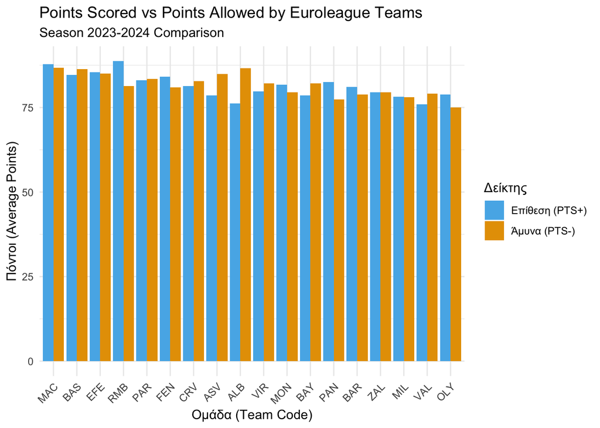

```r
# 1. Δημιουργία σύντομων ονομάτων ομάδων (Team Codes)
euro_data$TeamCode <- c(
  "ASV", "MIL", "BAR", "BAS", "ALB", "FEN",
  "EFE", "RMB", "MON", "BAY", "OLY", "PAN",
  "PAR", "CRV", "MAC", "VAL", "VIR", "ZAL"
)

# 2. Μετατροπή δεδομένων σε "long" μορφή για τη σύγκριση
# Προσοχή: Χρησιμοποιούμε τα ονόματα PTS. (Επίθεση) και PTS..1 (Άμυνα)
euro_long <- tidyr::pivot_longer(
  euro_data,
  cols = c(PTS., PTS..1),
  names_to = "Type",
  values_to = "Points"
)

# 3. Δημιουργία Bar Chart
ggplot(euro_long, aes(x = reorder(TeamCode, -Points), y = Points, fill = Type)) +
  geom_bar(stat = "identity", position = "dodge") +
  scale_fill_manual(values = c("PTS." = "#56B4E9", "PTS..1" = "#E69F00"),
                    labels = c("Επίθεση (PTS+)", "Άμυνα (PTS-)")) +
  labs(
    title = "Points Scored vs Points Allowed by Euroleague Teams",
    subtitle = "Season 2023-2024 Comparison",
    x = "Ομάδα (Team Code)",
    y = "Πόντοι (Average Points)",
    fill = "Δείκτης"
  ) +
  theme_minimal() +
  theme(axis.text.x = element_text(angle = 45, hjust = 1))
```

### Ερμηνεία Διαγράμματος

Στο παραπάνω γράφημα, η σύγκριση γίνεται μέσω των δύο χρωμάτων:

- **Γαλάζιο (PTS+) - Επίθεση:** Όσο πιο ψηλή είναι η γαλάζια μπάρα, τόσο πιο αποτελεσματική είναι η επίθεση της ομάδας.
- **Πορτοκαλί (PTS-) - Άμυνα:** Όσο πιο ψηλή είναι η πορτοκαλί μπάρα, τόσο περισσότερους πόντους δέχεται η ομάδα (άρα τόσο πιο “ευάλωτη” είναι η άμυνά της).

### Στρατηγικά Συμπεράσματα

Αναλύοντας τις κορυφές και τις βάσεις του διαγράμματος, προκύπτουν τα εξής:

- **Καλύτερη Επίθεση: RMB (Ρεάλ Μαδρίτης)** Εμφανίζει την υψηλότερη γαλάζια μπάρα στη διοργάνωση.
- **Χειρότερη Επίθεση: VAL (Βαλένθια)** Εμφανίζει τη χαμηλότερη γαλάζια μπάρα, υποδεικνύοντας δυσκολία στο σκοράρισμα.
- **Καλύτερη Άμυνα: OLY (Ολυμπιακός)** Εμφανίζει την πιο χαμηλή πορτοκαλί μπάρα, γεγονός που σημαίνει ότι περιορίζει τους αντιπάλους του περισσότερο από κάθε άλλη ομάδα.
- **Χειρότερη Άμυνα: MAC (Μακάμπι)** Εμφανίζει την υψηλότερη πορτοκαλί μπάρα, δεχόμενη τους περισσότερους πόντους ανά αγώνα.

### Επιχειρηματική Σύνοψη

Η ιδανική κατάσταση για μια ομάδα είναι η γαλάζια μπάρα να είναι αισθητά ψηλότερη από την πορτοκαλί.

Ομάδες όπου η **πορτοκαλί μπάρα ξεπερνά τη γαλάζια**, αντιμετωπίζουν στρατηγικό πρόβλημα, καθώς δέχονται περισσότερους πόντους από όσους παράγουν, κάτι που συνήθως οδηγεί σε χαμηλότερη θέση στη βαθμολογία.

## 4. Κατανομή Επιθετικής Επίδοσης

**Σκοπός:** Η παρουσίαση της κατανομή των πόντων που σκοράρουν οι ομάδες της Euroleague. Μέσα από το διάγραμμα μπορούμε να δούμε σε ποια εύρη πόντων συγκεντρώνονται οι περισσότερες ομάδες και να κατανοήσουμε καλύτερα το επίπεδο της επιθετικής τους απόδοσης.

**Ερώτημα:** Σε ποιο εύρος πόντων σκοράρουν οι περισσότερες ομάδες της Euroleague;

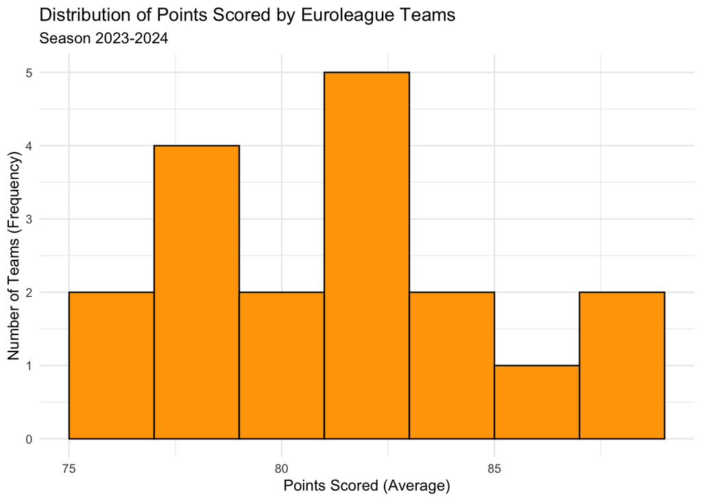

```r
# Δημιουργία Histogram για τους πόντους επίθεσης (PTS.)
ggplot(euro_data, aes(x = PTS.)) +
  geom_histogram(binwidth = 2, fill = "orange", color = "black") +
  labs(
    title = "Distribution of Points Scored by Euroleague Teams",
    subtitle = "Season 2023-2024",
    x = "Points Scored (Average)",
    y = "Number of Teams (Frequency)"
  ) +
  theme_minimal()
```

### Ερμηνεία Διαγράμματος

Από το διάγραμμα παρατηρούμε τα εξής στοιχεία για την επιθετική λειτουργία των ομάδων:

- **Κύρια Συγκέντρωση:** Οι περισσότερες ομάδες βρίσκονται περίπου μεταξύ **80 και 83 πόντων**. Αυτό σημαίνει ότι οι περισσότερες επιδόσεις στη διοργάνωση συγκεντρώνονται γύρω από αυτό το σημείο, που αποτελεί και το “benchmark” της λίγκας.
- **Ακραίες Επιδόσεις:** Υπάρχουν επίσης λίγες ομάδες με χαμηλότερους πόντους (**γύρω στους 75-78**) και κάποιες με υψηλότερους (**85-88**), αλλά αυτές εμφανίζονται πιο σπάνια (είναι οι λεγόμενες “ουρές” της κατανομής).
- **Συμπέρασμα:** Η κατανομή επιβεβαιώνει την εικόνα μιας πολύ ανταγωνιστικής διοργάνωσης, όπου η πλειοψηφία των ομάδων έχει παραπλήσια επιθετική παραγωγικότητα.

# Περιγραφική Στατιστική Ανάλυση

Στην ενότητα αυτή υπολογίζουμε τα βασικά μέτρα κεντρικής τάσης και διασποράς για τους κύριους δείκτες απόδοσης των ομάδων. Η ανάλυση αυτή μας επιτρέπει να κατανοήσουμε τον “μέσο όρο” της διοργάνωσης και το πόσο μεγάλη είναι η απόκλιση μεταξύ των ομάδων.

## Κεντρική Τάση & Διασπορά (Πόντοι, Ασίστ, Λάθη)

```r
# Επιλογή των βασικών μεταβλητών για στατιστική ανάλυση
stats_data <- euro_data %>%
  select(PTS., PTS..1, AST, TOV)

# Υπολογισμός Μέσου Όρου, Διαμέσου, Τυπικής Απόκλισης, Ελάχιστου και Μέγιστου
summary_stats <- data.frame(
  Μέσος_Όρος = sapply(stats_data, mean, na.rm = TRUE),
  Διάμεσος = sapply(stats_data, median, na.rm = TRUE),
  Τυπ_Απόκλιση = sapply(stats_data, sd, na.rm = TRUE),
  Ελάχιστο = sapply(stats_data, min, na.rm = TRUE),
  Μέγιστο = sapply(stats_data, max, na.rm = TRUE)
)

# Υπολογισμό Εύρους (Range) και Διακύμανσης (Variance)
summary_stats$Εύρος = summary_stats$Μέγιστο - summary_stats$Ελάχιστο
summary_stats$Διακύμανση = summary_stats$Τυπ_Απόκλιση^2

# Προβολή του πίνακα στατιστικών
datatable(round(summary_stats, 2), options = list(dom = 't'),
          caption = "Πίνακας Περιγραφικών Στατιστικών (PTS+, PTS-, AST, TOV)")
```

|  | Μέσος_Όρος | Διάμεσος | Τυπ_Απόκλιση | Ελάχιστο | Μέγιστο | Εύρος | Διακύμανση |
| --- | --- | --- | --- | --- | --- | --- | --- |
| PTS. | 81.44 | 81.2 | 3.67 | 75.9 | 88.7 | 12.8 | 13.45 |
| PTS..1 | 81.66 | 81.75 | 3.43 | 75 | 86.8 | 11.8 | 11.78 |
| AST | 17.56 | 17.7 | 1.59 | 15.1 | 20.6 | 5.5 | 2.53 |
| TOV | 12.36 | 12.4 | 1.1 | 10 | 15.1 | 5.1 | 1.22 |

### Στρατηγική Ανάλυση των Αποτελεσμάτων

#### 1. Επίθεση vs Άμυνα (PTS. & PTS..1)

- **Ισορροπία Πόντων:** Ο Μέσος Όρος επίθεσης (**81.44**) και άμυνας (**81.66**) είναι σχεδόν ταυτόσημοι. Αυτό δείχνει μια εξαιρετικά ανταγωνιστική λίγκα όπου τα παιχνίδια κρίνονται στις λεπτομέρειες.
- **Ομοιομορφία:** Η χαμηλή Τυπική Απόκλιση (**3.67** και **3.43**) δείχνει ότι οι περισσότερες ομάδες παίζουν στο ίδιο τέμπο. Δεν υπάρχουν “σάκοι του μποξ” ή ομάδες που σκοράρουν 100 πόντους σταθερά.
- **Το Χάσμα (Εύρος):** Το εύρος των **12.8 μονάδων** στην επίθεση είναι σημαντικό. Δείχνει ότι η απόσταση μεταξύ της καλύτερης επίθεσης (**88.7**) και της χειρότερης (**75.9**) είναι περίπου 5 κατοχές ανά αγώνα, μια διαφορά που καθορίζει την πρόκριση στα Playoffs.

#### 2. Δημιουργία και Ομαδικότητα (AST)

- **Benchmark Ασσίστ:** Ο Μέσος Όρος των **17.56** ασίστ αποτελεί το “χρυσό κανόνα” της διοργάνωσης. Ομάδες που προσεγγίζουν το Μέγιστο (**20.6**) θεωρούνται ελίτ στη δημιουργία, ενώ το Ελάχιστο (**15.1**) φανερώνει ομάδες με πιο ατομικό στυλ παιχνιδιού.
- **Συνοχή:** Η πολύ μικρή Διακύμανση (**2.53**) υποδηλώνει ότι η “κουλτούρα της πάσας” είναι κοινή σε όλη τη διοργάνωση, με τις περισσότερες ομάδες να στοχεύουν στο ομαδικό μπάσκετ.

#### 3. Διαχείριση Λαθών (TOV)

- **Επίπεδο Συγκέντρωσης:** Με Μέσο Όρο τα **12.36** λάθη και πολύ μικρή Τυπική Απόκλιση (**1.1**), παρατηρούμε ότι το επίπεδο προσοχής είναι παρόμοιο σε όλες τις ομάδες.
- **Η Κρίσιμη Διαφορά:** Μια ομάδα που βρίσκεται στο Μέγιστο των λαθών (**15.1**) χάνει 5 περισσότερες κατοχές από μια ομάδα στο Ελάχιστο (**10.0**). Σε κλειστές αναμετρήσεις, αυτές οι 5 κατοχές μεταφράζονται συνήθως σε ήττα.

### Τελικό Συμπέρασμα Περιγραφικής Ανάλυσης

Η **Διάμεσος** συμπίπτει σχεδόν απόλυτα με τον **Μέσο Όρο** σε όλες τις κατηγορίες, γεγονός που σημαίνει ότι τα δεδομένα ακολουθούν την **κανονική κατανομή** χωρίς ακραίες τιμές που να αλλοιώνουν την εικόνα.

Όσον αφορά την **Επικρατούσα Τιμή (Mode)**, παρατηρούμε ότι στα περισσότερα στατιστικά δεν υπάρχει μία μοναδική τιμή που να επαναλαμβάνεται συχνά, καθώς τα δεδομένα είναι συνεχή. Ωστόσο, η συγκέντρωση των τιμών γύρω από τον μέσο όρο επιβεβαιώνει τη μεγάλη ομοιογένεια των ομάδων της Euroleague για τη σεζόν 2023-24.

Η διοργάνωση αποδεικνύεται μια λίγκα “των προπονητών”, όπου οι ομάδες είναι πολύ κοντά στα βασικά στατιστικά και η διαφορά γίνεται από την ποιότητα της εκτέλεσης και την αμυντική πειθαρχία.

# Διερεύνηση Συσχετίσεων

Σε αυτή την ενότητα εξετάζουμε πώς επηρεάζει η μία μεταβλητή την άλλη. Χρησιμοποιούμε τον συντελεστή συσχέτισης του Pearson για να εντοπίσουμε τις πιο ισχυρές σχέσεις στο παιχνίδι.

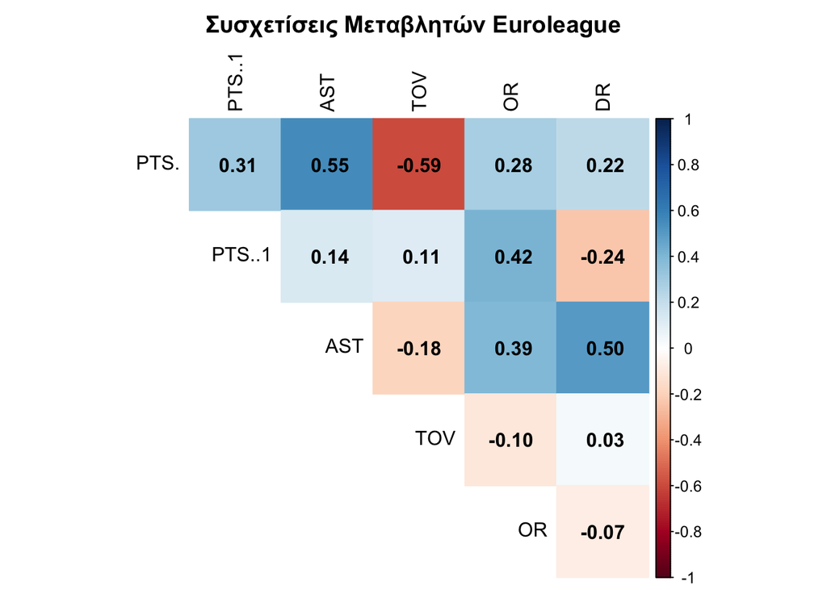

```r
library(corrplot)
# Επιλογή των αριθμητικών μεταβλητών που θέλουμε να αναλύσουμε
corr_data <- euro_data %>%
  select(PTS., PTS..1, AST, TOV, OR, DR)

# Υπολογισμός μήτρας συσχέτισης
cor_matrix <- cor(corr_data, use = "complete.obs")

# Οπτικοποίηση με Corrplot
corrplot(cor_matrix, method = "color",
         type = "upper",
         addCoef.col = "black",
         tl.col = "black",
         diag = FALSE,
         title = "Συσχετίσεις Μεταβλητών Euroleague",
         mar = c(0,0,2,0))
```

### Ερμηνεία Συντελεστών Συσχέτισης

Με βάση τον πίνακα συσχετίσεων, εντοπίζουμε τις παρακάτω κρίσιμες σχέσεις που καθορίζουν τη στρατηγική των ομάδων:

#### 1. Η Δύναμη της Δημιουργίας (AST & PTS.)

- **Συντελεστής:** **0.55** (Θετική Συσχέτιση)
- **Ερμηνεία:** Οι Ασίστ έχουν την ισχυρότερη θετική επίδραση στο σκοράρισμα. Για κάθε αύξηση στην ομαδική δημιουργία, παρατηρούμε σημαντική άνοδο στους πόντους της επίθεσης. Το ομαδικό μπάσκετ είναι ο “κινητήρας” της παραγωγικότητας.

#### 2. Το Κόστος των Λαθών (TOV & PTS.)

- **Συντελεστής:** **-0.59** (Ισχυρή Αρνητική Συσχέτιση)
- **Ερμηνεία:** Αυτή είναι η πιο ισχυρή σχέση στο διάγραμμα. Η αρνητική τιμή σημαίνει ότι όσο αυξάνονται τα λάθη, τόσο **μειώνονται** οι πόντοι της ομάδας. Τα Turnovers “σκοτώνουν” την επίθεση στερώντας κατοχές και ρυθμό.

#### 3. Η Σχέση Ριμπάουντ και Δημιουργίας (OR, DR & AST)

- **Συντελεστής:** **0.39** (με OR) και **0.50** (με DR)
- **Ερμηνεία:** Υπάρχει αξιοσημείωτη σχέση μεταξύ των ριμπάουντ και των ασίστ. Ειδικά το αμυντικό ριμπάουντ (0.50) επιτρέπει στις ομάδες να ξεκινήσουν γρήγορες επιθέσεις (transition), οι οποίες καταλήγουν συχνά σε ασίστ και εύκολους πόντους.

#### 4. Παθητικό και Λάθη (TOV & PTS..1)

- **Συντελεστής:** **0.11** (Σχεδόν μηδενική συσχέτιση)
- **Ερμηνεία:** Επιβεβαιώνεται στατιστικά ότι τα λάθη της επίθεσης δεν οδηγούν υποχρεωτικά σε περισσότερους πόντους από τον αντίπαλο. Η άμυνα μιας ομάδας μπορεί να είναι αποτελεσματική ακόμα και αν η επίθεση είναι επιρρεπής στα λάθη.

### Επιχειρηματικό Συμπέρασμα Συσχετίσεων

Η ανάλυση δείχνει ότι αν ένας προπονητής θέλει να βελτιώσει άμεσα την ομάδα του, πρέπει να εστιάσει σε δύο άξονες:

1. **Μείωση των Λαθών (TOV):** Είναι ο παράγοντας που επηρεάζει περισσότερο από κάθε άλλον το σκοράρισμα αρνητικά (**-0.59**).
2. **Ενίσχυση της Δημιουργίας (AST):** Η καλή κυκλοφορία (**0.55**) είναι η “απάντηση” για μια επιτυχημένη επίθεση.

Εντύπωση προκαλεί η σχέση **PTS. με PTS..1 (0.31)**, η οποία δείχνει ότι οι ομάδες με πολύ καλή επίθεση τείνουν να δέχονται και περισσότερους πόντους, πιθανώς λόγω του υψηλού ρυθμού (Pace) των αγώνων τους.